# Assessing Macrophage Activation and Response to Bacterial Infection *in vitro*

Examination Number: Y3856686

February, 2021

# 1 Introduction

Macrophages are mononuclear cells with high phagocytic activity, (Schnyder and Baggiolini 1978). They have key roles in the immune responses, particularly the production of proinflammatory cytokines and the phagocytosis of microorganisms, (Murray et al. 2005).

Phagocytosis is a major function of the macrophage, not only for pathogens, but also for the resolution of inflammation through the phagocytosis of other immune cells, such as neutrophils, (Newman, Henson, and Henson 1982).

The necrosis of tumours in response to bacterial-endotoxins was first determined to be an indirect process by, (O’Malley, Achinstein, and Shear 1962), in which the necrosis could be triggered by a serum, derived from animals treated with lipopolysaccharides (LPS), in animals not exposed to LPS. This was deemed to be mediated by a “tumour necrotizing factor” later determined to be a superfamily that includes the protein Tumour Necrosis Factor-$\alpha$ (TNF-$\alpha$).

Understanding the mechanisms by which macrophages are activated, and their subsequent production of TNF-$\alpha$, is important for aiding research into chronic inflammatory diseases such as rheumatoid arthritis and multiple sclerosis, (Plevy et al. 1997). Uncontrolled macrophage activation is noted to be key in such chronic inflammatory diseases, (Sindrilaru et al. 2011), with TNF-$\alpha$ being classed as a proinflammatory macrophage marker.

The aim of this study is to gain understanding of the mechanisms by which macrophages are activated/respond and produce TNF-$\alpha$, specifically with regards to the necessity of phagocytosis in the production of TNF-$\alpha$.

# 2 Is phagocytosis required to trigger the production of TNF-$\alpha$ by macrophages?

The TNF-$\alpha$ production from RAW 264.7 cells is shown in Figures 2.1 and 2.2. Membranes from the SDS-PAGE were incubated with the primary antibody solution, rabbit anti-TNF-$\alpha$ in TBS-T with 5% milk, and consequently incubated with the secondary antibody solution, goat anti-rabbit IgG-linked to horseradish peroxidase in PBS-T in milk.

All cells were treated with Brefeldin-A, an inhibitor of protein transport and secretion, in order to enhance the intracellular cytokine (TNF-$\alpha$) staining signal for the Western Blot Analysis.

Figure 2.1 indicates that only RAW 264.7 cells treated with 100 ng/ml LPS from *E.coli* and RAW 264.7 cells treated with *E.coli* bacteria produced TNF-$\alpha$, as shown by the bands labelled B1, B2, C1 and C2 respectively.

Figure 2.2, illustrates the calculation of the molecular weights of the labelled bands from Figure 2.1, using the calculated molecular weights of the molecular marker bands. From the calculated molecular weights of Figure 2.2, the identity of the bands on the Western Blot can be confirmed to be that of TNF-$\alpha$.

Bands B1 and C1 calculated to be 28.3 kDa and 27.11 kDa respectively. Bands B2 and C2 calculated to be 22.9 kDa and 23.89 kDa respectively. These were compared to the datasheet, (CellSignal 2017) and (UniProtConsortium 2019), to confirm the identification of the TNF-$\alpha$ bands.

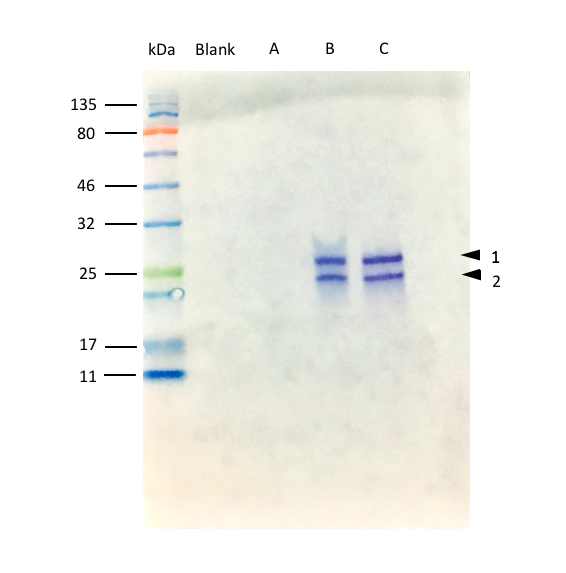

Figure 2.1: Western blot from SDS-PAGE, analysis of TNF-$\alpha$ in RAW 264.7 cells treated with Brefeldin-A.  
(A) Untreated RAW 264.7 cells  
**(B)** RAW 264.7 cells treated with 100 ng/ml LPS from *E.coli*  
**(C)** RAW 264.7 cells treated with *E.coli* bacteria

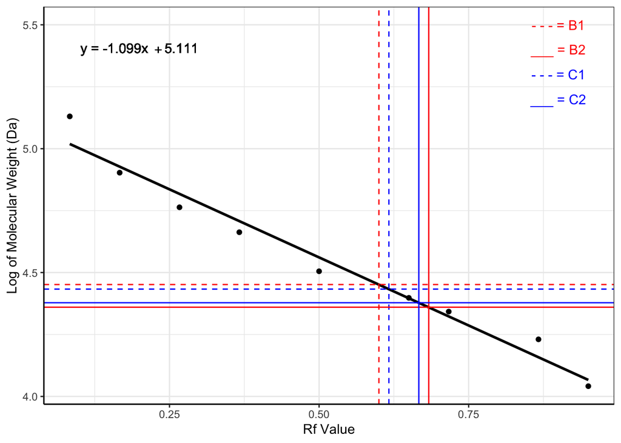

Figure 2.2: **Identification of the Molecular Weight of TNF-$\alpha$ using Rf values**  
**Dashed Red** - B1 band shown in Figure 2.1, **Red** - B2 band shown in Figure 2.1, **Dashed Blue** - C1 band shown in Figure 2.1, **Blue** - C2 band shown in Figure 2.1.

# 3 Determining the level of TNF-$\alpha$ expression using Flow Cytometry

The western blotting results looked at the overall effect of LPS and bacteria on a population of cells, without distinction between individual cells. Flow cytometry can be used to analyse the production of TNF-$\alpha$ by individual RAW 264.7 macrophage cells.

## 3.1 Principles of Flow Cytometry

Flow cytometry involves a cell susupension being passed through a flow chamber, so that cells pass in front of lasers one-by-one. This results in light being scattered and detected by forward and side scatter detectors, allowing the determination of size and granularity. Fluorescence detectors also detect any fluorescently tagged cells for identification of specific markers.

For an overview of the technique please see the video, (mitedustar 2015).

[video not shown]

# 4 Methods for Data Analysis

For general data tidying and organisation the “tidyverse” package, (Wickham et al. 2019), was used.

The processing and analysis of the flow cytometry data was carried out using the Bioconductor package “flowCore”, (Ellis et al. 2020). Visualisation of the flow cytometry data was carried out using the packages “ggcyto”, (Van et al. 2018) and “ggplot2”, (Wickham 2016).

Arrangement of plots were made using “patchwork”, (Pedersen 2020).

For more information on the Bioconductor packages please see the [website](https://www.bioconductor.org/).

# 5 Data Import and Tidying

The data contains two samples:

**Sample 1:** treated with Brefeldin A only (Unstimulated) 1A: not stained 1B: stained for intracellular TNF-$\alpha$ production, detected with an anti-rabbit 488 (Green)

**Sample 2:** treated with Brefeldin A and red-fluorescent (rhodamine) bacteria (Stimulated LPS Treated) 2A: not stained 2B: stained for intracellular TNF-$\alpha$ production, detected with an anti-rabbit 488 (Green)

```r
file1A <- "data-raw/class-sample/class 1A.fcs"
fcm1A <- read.FCS(file1A, alter.names = TRUE)

file1B <- "data-raw/class-sample/class 1B.fcs"
fcm1B <- read.FCS(file1B, alter.names = TRUE)

file2A <- "data-raw/class-sample/class 2A.fcs"
fcm2A <- read.FCS(file2A, alter.names = TRUE)

file2B <- "data-raw/class-sample/class 2B.fcs"
fcm2B <- read.FCS(file2B, alter.names = TRUE)
```

## 5.1 Compensation

When using more than one fluorochrome, there is the possibility for their emission spectra to overlap. The overlap is often termed ‘spillover’ and this needs to be removed from the flow cytometry data through a process called compensation, (O’Neill et al. 2013).

```r
# each FCS file should contain compensation data

#Sample 1A
spillover(fcm1A) #check to see which keyword the compensation data is under

# names in spillover matrix don't match the flowFrame so need to change the matrix colnames

matrix1A <- spillover(fcm1A)$`$SPILLOVER`
matrix1A
colnames(matrix1A) <- c("FL.1.Log", "FL.3.Log", "FL.4.Log")

fcm1A_comp <- compensate(fcm1A, matrix1A)

# repeat for each file

#Sample 1B
spillover(fcm1B)

matrix1B <- spillover(fcm1B)$`$SPILLOVER`
matrix1B
colnames(matrix1B) <- c("FL.1.Log", "FL.3.Log", "FL.4.Log")

fcm1B_comp <- compensate(fcm1B, matrix1B)

#Sample 2A
spillover(fcm2A)

matrix2A <- spillover(fcm2A)$`$SPILLOVER`
matrix2A
colnames(matrix2A) <- c("FL.1.Log", "FL.3.Log", "FL.4.Log")

fcm2A_comp <- compensate(fcm2A, matrix2A)

#Sample 2B
spillover(fcm2B)

matrix2B <- spillover(fcm2B)$`$SPILLOVER`
matrix2B
colnames(matrix2B) <- c("FL.1.Log", "FL.3.Log", "FL.4.Log")

fcm2B_comp <- compensate(fcm2B, matrix2B)
```

## 5.2 Transformation

This step is carried out in order to visualise the data more easily as many of the channels are not in a log format, the code used in this step transforms the data into a “logicle” format, other transformations can be used here instead if needed. However, for this report the log channel data is used.

```r
trans1A <- estimateLogicle(fcm1A_comp, colnames(fcm1A_comp[, c(1:5, 7:8, 10:11, 13:14, 16:17,
                                                               19:20, 22:23, 25:26, 28:29, 31:32, 24:35)]))
fcm1A_comp_trans <- transform(fcm1A_comp, trans1A)


trans1B <- estimateLogicle(fcm1B_comp, colnames(fcm1B_comp[, c(1:5, 7:8, 10:11, 13:14, 16:17,
                                                               19:20, 22:23, 25:26, 28:29, 31:32, 24:35)]))
fcm1B_comp_trans <- transform(fcm1B_comp, trans1B)

trans2A <- estimateLogicle(fcm2A_comp, colnames(fcm2A_comp[, c(1:5, 7:8, 10:11, 13:14, 16:17,
                                                               19:20, 22:23, 25:26, 28:29, 31:32, 24:35)]))
fcm2A_comp_trans <- transform(fcm2A_comp, trans2A)

trans2B <- estimateLogicle(fcm2B_comp, colnames(fcm2B_comp[, c(1:5, 7:8, 10:11, 13:14, 16:17,
                                                               19:20, 22:23, 25:26, 28:29, 31:32, 24:35)]))
fcm2B_comp_trans <- transform(fcm2B_comp, trans2B)
```

# 6 Results

## 6.1 Initial Gating of Samples

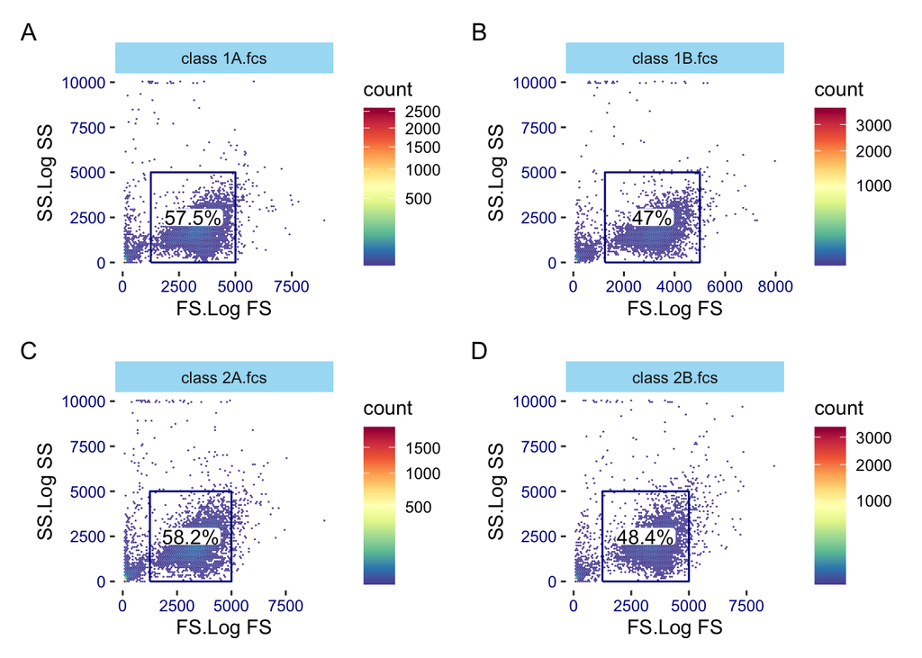

Figure 6.1: **Forward-side scatter plots of RAW 264.7 cells by flow cytometry to show gating of live cells**  
**(A)** Unstimulated, non-stained cells. **(B)** Unstimulated cells stained with anti-TNF$\alpha$. **(C)** Macrophages exposed to red-fluorescent (rhodamine) bacteria, without anti-TNF$\alpha$ labelling. **(D)** Macrophages exposed to red-fluorescent (rhodamine) bacteria, with anti-TNF$\alpha$ labelling. The same gating was applied to all samples.

## 6.2 Detection of TNF-$\alpha$

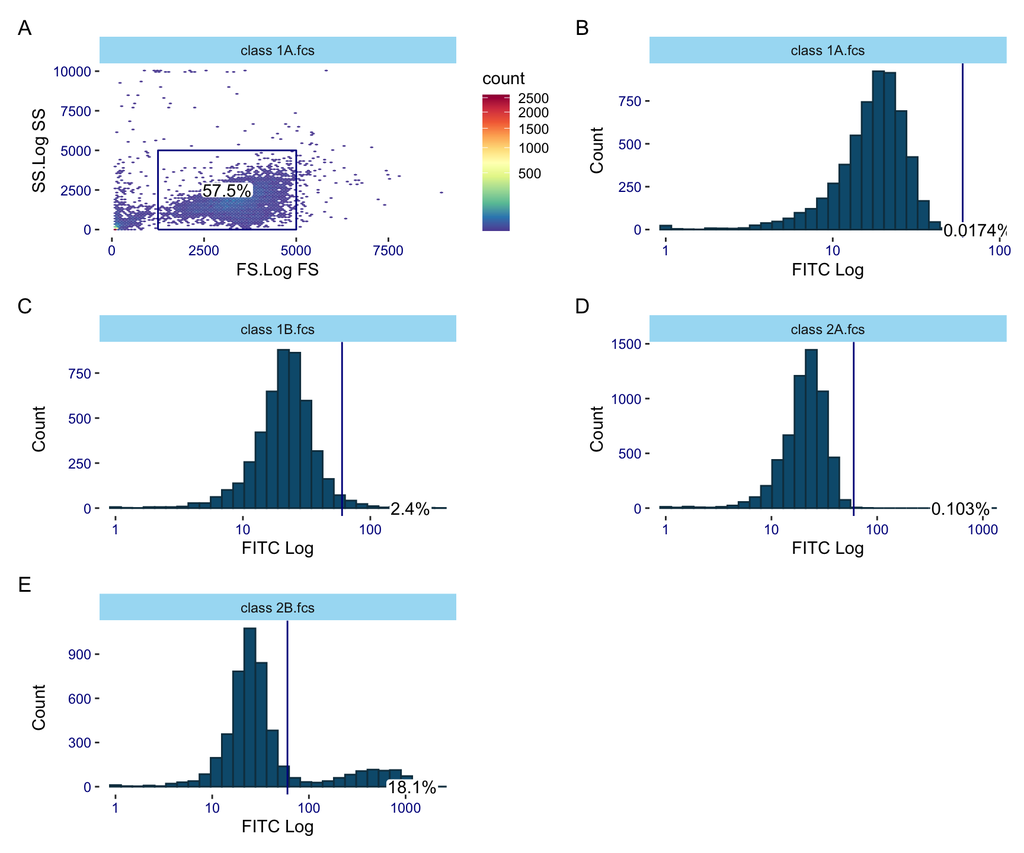

Figure 6.2: **Detection of TNF$\alpha$ in RAW 264.7 cells stimulated with or without red fluorescent (rhodamine) bacteria by flow cytometry**  
**(A)** Forward-side scatter of unstimulated, non-stained cells to show live gating of cells. Gated cells used to produce fluorescence histograms. The same gating was applied to all samples. **(B)** Unstimulated, cells stained without anti-TNF$\alpha$. Gating for TNF$\alpha$ positive cells. **(C)** Unstimulated cells stained with anti-TNF$\alpha$. Gating for TNF$\alpha$ positive cells shows the absence of residual TNF$\alpha$ production. **(D)** Cells stimulated with red fluorescent (rhodamine) bacteria labelled without anti-TNF$\alpha$. Gating for TNF$\alpha$ positive cells. **(E)** Cells stimulated with red fluorescent (rhodamine) bacteria labelled with anti-$\alpha$. Gating for TNF$\alpha$ positive cells shows TNF$\alpha$ production by bacteria stimulated macrophages.

Table 6.1: Summary statistics obtained from flow cytometry analysis comparing the production of fluorecently labelled TNF-$\alpha$ by macrophages stimulated with (+) or without (-) red fluorescent (rhodamine) bacteria

| Bacteria Stimulation | Anti TNF Stain | Cell Count | Cells Positive for TNF | Percentage Cells Positive For TNF | Mean Fluorescence Intensity | Median Fluorescence Intensity |
| --- | --- | --- | --- | --- | --- | --- |
| - | - | 5753 | 1 | 0.0173822 | 18.54365 | 18.31287 |
| - | + | 4704 | 113 | 2.4022109 | 24.41287 | 21.83290 |
| + | - | 5816 | 6 | 0.1031637 | 22.48916 | 21.59032 |
| + | + | 4840 | 875 | 18.0785124 | 110.36992 | 26.69827 |

TNF-$\alpha$ was shown to be produced by cells exposed to bacteria (Figure 6.2). 18.08% of the bacteria stimulated cells were shown to be positive for TNF-$\alpha$, compared to 2.4% of unstimulated cells. The stimulated macrophages also displayed greater mean fluorescence intensity values than unstimulated cells (Table 6.1).

## 6.3 Detection of bacteria uptake

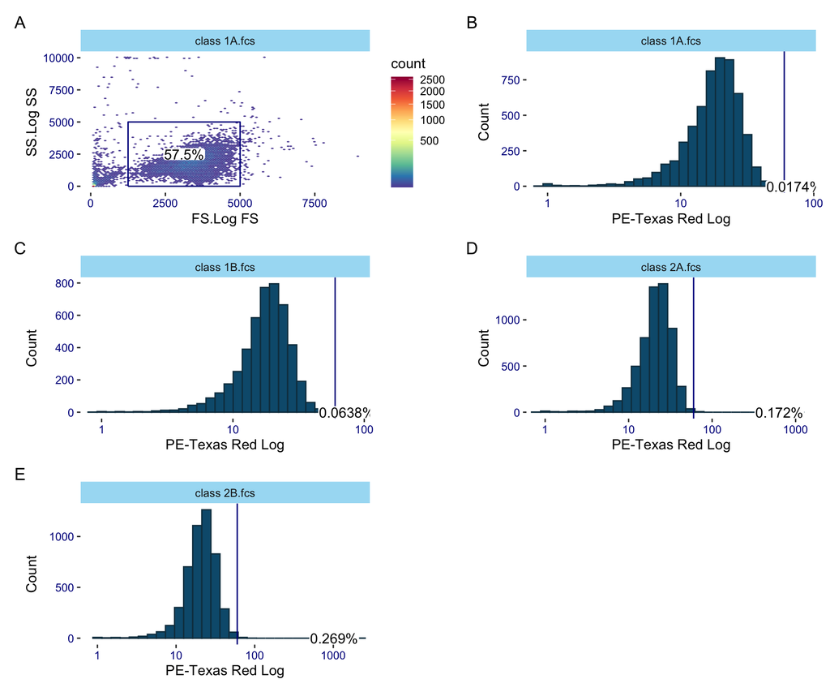

Figure 6.3: **Detection of red fluorescent (rhodamine) bacteria uptake in RAW 264.7 cells stimulated with or without red fluorescent (rhodamine) bacteria by flow cytometry**  
**(A)** Forward-side scatter of unstimulated, non-stained cells to show live gating of cells. Gated cells used to produce fluorescence histograms. The same gating was applied to all samples. **(B)** Unstimulated, cells stained without anti-TNF$\alpha$. Gating for rhodamine bacteria positive cells. **(C)** Unstimulated cells stained with anti-TNF$\alpha$. Gating for rhodamine bacteria positive cells. **(D)** Cells stimulated with red fluorescent (rhodamine) bacteria labelled without anti-TNF$\alpha$. Gating for rhodamine bacteria positive cells. **(E)** Cells stimulated with red fluorescent (rhodamine) bacteria labelled with anti-$\alpha$. Gating for rhodamine bacteria positive cells.

Table 6.2: Summary statistics obtained from flow cytometry analysis comparing the uptake of bacteria and TNF-$\alpha$ production in macrophages stimulated with (+) or without (-) red fluorescent (rhodamine) bacteria

| Bacteria Stimulation | Anti TNF Stain | Cell Count | Cells Positive for Bacteria | Percentage Cells Positive For Bacteria | Mean PE Texas Red Fluorescence Intensity | Median PE Texas Red Fluorescence Intensity |
| --- | --- | --- | --- | --- | --- | --- |
| - | - | 5753 | 1 | 0.0173822 | 82.69369 | 82.69369 |
| - | + | 4704 | 3 | 0.0637755 | 74.15981 | 73.57104 |
| + | - | 5816 | 10 | 0.1719395 | 227.25398 | 65.15587 |
| + | + | 4840 | 13 | 0.2685950 | 216.62075 | 66.74222 |

## 6.4 Comparison of TNF-$\alpha$ production and bacteria uptake

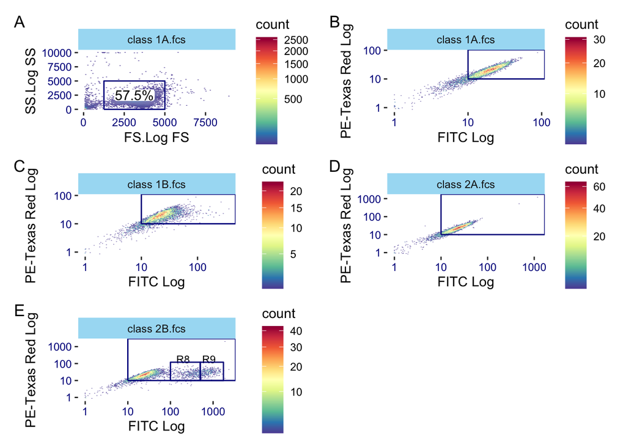

Figure 6.4: **Detection of red fluorescent (rhodamine) bacteria uptake and TNF-$\alpha$ in RAW 264.7 cells stimulated with or without red fluorescent (rhodamine) bacteria by flow cytometry**  
**(A)** Forward-side scatter of unstimulated, non-stained cells to show live gating of cells. The same gating was applied to all samples. **(B)** Unstimulated, cells stained without anti-TNF$\alpha$. **(C)** Unstimulated cells stained with anti-TNF$\alpha$. **(D)** Cells stimulated with red fluorescent (rhodamine) bacteria labelled without anti-TNF$\alpha$. **(E)** Cells stimulated with red fluorescent (rhodamine) bacteria labelled with anti-$\alpha$. Two distinct populations of cells denoted by R8 and R9 gates. R8 gate is representative of cells positive for TNF-$\alpha$ only (single positive cells). R9 gate is representative of double positive cells, displaying bacteria uptake and TNF-$\alpha$ production.

A greater mean red fluorescence intensity was observed in the cell samples exposed to bacteria than the unstimulated population, providing some evidence of phagocytosis (Tabel 6.2). A scatter plot produced from macrophages exposed to bacteria identifies two distinct populations of cells (Figure 6.4). The R8 gate represents a population of single positive cells that produce TNF-$\alpha$ only. The double positive population is denoted by R9, which is positive for both TNF-$\alpha$ and bacteria uptake.

# 7 Word Count

Word count calculated using (Marwick 2020).

**Word Count for Markdown:** 1623

**Word Count for README file:** 373

**Total Word Count:** 1996

All inline citations and references were produced using the “citr” package, (Aust 2019).

# References

Aust, Frederik. 2019. *Citr: ’RStudio’ Add-in to Insert Markdown Citations*. https://github.com/crsh/citr.

CellSignal. 2017. “CST - TNF-$\alpha$ (D2D4) XP Rabbit mAb (Mouse Specific).” https://www.cellsignal.com/products/primary-antibodies/tnf-a-d2d4-xp-rabbit-mab-mouse-specific/11948?_=1550331868211&Ntt=TNF-alpha&tahead=true. https://www.cellsignal.com/products/primary-antibodies/tnf-a-d2d4-xp-rabbit-mab-mouse-specific/11948?_=1550331868211&Ntt=TNF-alpha&tahead=true.

Ellis, B, Perry Haaland, Florian Hahne, Nolwenn Le Meur, Nishant Gopalakrishnan, Josef Spidlen, Mike Jiang, and Greg Finak. 2020. *FlowCore: FlowCore: Basic Structures for Flow Cytometry Data*.

Marwick, Ben. 2020. *Wordcountaddin: Word Counts and Readability Statistics in R Markdown Documents*.

mitedustar. 2015. “Flow Cytometry Animation.” Youtube. https://www.youtube.com/watch?v=EQXPJ7eeesQ.

Murray, Rachael Z, Jason G Kay, Daniele G Sangermani, and Jennifer L Stow. 2005. “A Role for the Phagosome in Cytokine Secretion.” *Science* 310 (5753): 1492–5. https://doi.org/10.1126/science.1120225.

Newman, S L, J E Henson, and P M Henson. 1982. “Phagocytosis of Senescent Neutrophils by Human Monocyte-Derived Macrophages and Rabbit Inflammatory Macrophages.” *J. Exp. Med.* 156 (2): 430–42. https://doi.org/10.1084/jem.156.2.430.

O’Malley, W Edward, Betty Achinstein, and Murray J Shear. 1962. “Action of Bacterial Polysaccharide on Tumors. II. Damage of Sarcoma 37 by Serum of Mice Treated with Serratia Marcescens Polysaccharide, and Induced Tolerance.” *J. Natl. Cancer Inst.* 29 (6): 1169–75. https://doi.org/10.1093/jnci/29.6.1169.

O’Neill, Kieran, Nima Aghaeepour, Josef Spidlen, and Ryan Brinkman. 2013. “Flow Cytometry Bioinformatics.” *PLoS Comput. Biol.* 9 (12): e1003365. https://doi.org/10.1371/journal.pcbi.1003365.

Pedersen, Thomas Lin. 2020. *Patchwork: The Composer of Plots*. https://CRAN.R-project.org/package=patchwork.

Plevy, S E, C J Landers, J Prehn, N M Carramanzana, R L Deem, D Shealy, and S R Targan. 1997. “A Role for TNF-alpha and Mucosal T Helper-1 Cytokines in the Pathogenesis of Crohn’s Disease.” *J. Immunol.* 159 (12): 6276–82. https://www.ncbi.nlm.nih.gov/pubmed/9550432.

Schnyder, J, and M Baggiolini. 1978. “Role of Phagocytosis in the Activation of Macrophages.” *J. Exp. Med.* 148 (6): 1449–57. https://doi.org/10.1084/jem.148.6.1449.

Sindrilaru, Anca, Thorsten Peters, Stefan Wieschalka, Corina Baican, Adrian Baican, Henriette Peter, Adelheid Hainzl, et al. 2011. “An Unrestrained Proinflammatory M1 Macrophage Population Induced by Iron Impairs Wound Healing in Humans and Mice.” *J. Clin. Invest.* 121 (3): 985–97. https://doi.org/10.1172/JCI44490.

UniProtConsortium. 2019. “Tnf - Tumor Necrosis Factor Precursor - Mus Musculus (Mouse) - Tnf Gene & Protein.” https://www.uniprot.org/uniprot/P06804. https://www.uniprot.org/uniprot/P06804.

Van, Phu, Wenxin Jiang, Raphael Gottardo, and Greg Finak. 2018. “ggcyto: Next-Generation Open-Source Visualization Software for Cytometry.” *Bioinformatics*. https://doi.org/10.1093/bioinformatics/bty441.

Wickham, Hadley. 2016. *Ggplot2: Elegant Graphics for Data Analysis*. Springer-Verlag New York. https://ggplot2.tidyverse.org.

Wickham, Hadley, Mara Averick, Jennifer Bryan, Winston Chang, Lucy D’Agostino McGowan, Romain François, Garrett Grolemund, et al. 2019. “Welcome to the tidyverse.” *Journal of Open Source Software* 4 (43): 1686. https://doi.org/10.21105/joss.01686.